# SlidesOfIntergatedCodeV2 slides

```python
from shape_utils import Rectangle,Point,HoughLine
import glob
import math
import numpy as np
import pandas as pd
import os
import time

import matplotlib.pyplot as plt
import cv2
import random as ran
from skimage.io import imread, imshow
from skimage.transform import resize
from skimage.feature import hog
from skimage import exposure
from sklearn.preprocessing import StandardScaler
from sklearn.model_selection import train_test_split
from sklearn import svm
import matplotlib.image as mpimg
from scipy.ndimage.measurements import label
import joblib
%matplotlib inline
```

## Last time :

#### We explained how we trained the model, now we are going to continue right from where we stopped

```python
model, testx ,testy =joblib.load("Vision.pkl");
scaler = joblib.load("Scaler.pkl");
```

## Our last result :

#### This image is what we were able to predict in the last model

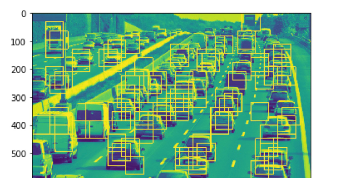

```python
plt.imshow(mpimg.imread("previous/heat_map_img.jpg"));
plt.axis("off");
```

# Going with the heatmaps!

### It is appearant from the previous image the great overlap between recognition boxes.

### The heatmap would be able to find `hottest areas` (recognized mulitiple times) and uniquly represent them with a single box.

## Functions for the model prediction

### Our model takes an image of a fixed shape to predict the its class. So, lets make a function that automatically `recizes` the input and `feeds` it into the support vector machines.

```python
def predOut(img2):
    from skimage.feature import hog

    img = img2.copy() # assumed 64x64
    img=cv2.resize(img, (64,64))
    img_hog = hog(img, orientations=9, pixels_per_cell=(16, 16),cells_per_block=(2, 2), visualize=False, multichannel=False)

    sc = scaler.transform(img_hog.reshape(1,-1))
    pred = model.predict(sc)

    return int(pred)
```

## Ok, what if the image had multiple cars? what if loose important details due to a great recize ratio?

### Instead of depending solely on `predout()`, we need to make some sort of moving window that captures parts of the image (with minimal recizing) and feed that into the model. This idea is commonly know as the `Sliding window`. Our function `reco()` does exactly that.

```python
def reco(img,div_size=None,win_sz=None,rand_selection=True,slide_ratio=1/4):
    ios = []
    img2 = img.copy()
    if (div_size!=None):
        new_x_dim = int(img2.shape[1]/div_size)
        new_y_dim = int(img2.shape[0]/div_size)
        img2 = cv2.resize(img2,(new_x_dim,new_y_dim))
        img2 = cv2.GaussianBlur(img2,(1,1),cv2.BORDER_DEFAULT) # don't know how much is needed

    copy1 = img2.copy()
    copy2 = img2.copy()

    if(win_sz==None):
        window_size = 64 # 64 X 64 this is the default window size
    else:
        window_size = win_sz

    window = np.ones((window_size,window_size))
    #   Sliding widow loop (not very efficent but works)
    i=0
    while (i + window_size) < (copy1.shape[0]) : # y , vertical
        j=0
        while (j + window_size) < (copy1.shape[1]): # x , horizontal

            window = copy1[i:window_size+i,j:window_size+j] # copy[vertical, horizontal]

            if predOut(window): # window
                if(np.random.randint(0,3)==0 and rand_selection): # 33.33% chance of drawing box = less boxes
                    copy2 = cv2.rectangle(copy2, (j,i), (j+window_size,i+window_size ), (255,0,0), 2)
                    ios.append((j,i))
                elif(not rand_selection):
                    copy2 = cv2.rectangle(copy2, (j,i), (j+window_size,i+window_size ), (255,0,0), 2)
                    #ios.append((j,i))
                    x1 = np.int( j +  window_size)
                    y1= np.int( i + window_size)
                    ios.append(((j,i),(x1,y1)))

            j+= int(window_size*slide_ratio)
        i+= int(window_size*slide_ratio)

    return copy2,ios #indecies of squares
```

```python
def Myheat(heatmap, bbox_list):

    for box in bbox_list:

        heatmap[box[0][1]:box[1][1], box[0][0]:box[1][0]] += 1


    return heatmap

def apply_threshold(heatmap, threshold):

    heatmap[heatmap <= threshold] = 0

    return heatmap
```

```python
def Mydraw(img, labels):
    img2 =np.copy(img)
    boxes = []
    for car_number in range(1, labels[1]+1):
        nonzero = (labels[0] == car_number).nonzero()
        nonzeroy = np.array(nonzero[0])
        nonzerox = np.array(nonzero[1])
        bbox = ((np.min(nonzerox), np.min(nonzeroy)), (np.max(nonzerox), np.max(nonzeroy)))
        boxes.append(bbox)
        cv2.rectangle(img2, bbox[0], bbox[1], (0,0,255), 6)


    return (img2,boxes)
```

```python
def recognize_full(img) :
    out,win1 = reco(img,div_size=1,win_sz=64,rand_selection=False,slide_ratio=0.25)
    out,win2 = reco(img,div_size=1,win_sz=80,rand_selection=False,slide_ratio=0.25)
    out,win3 = reco(img,div_size=1,win_sz=128,rand_selection=False,slide_ratio=0.25)
    out,win4 = reco(img,div_size=1,win_sz=96,rand_selection=False,slide_ratio=0.25)
    wins = win1 + win2+win3+win4



    heat = np.zeros_like(image[:,:,0]).astype(np.float)
    heat = Myheat(heat,wins)
    # Apply threshold to help remove false positives
    heat = apply_threshold(heat,8)
    heatmap = np.clip(heat, 0, 255)
    heat_image=heatmap
    # Find final boxes from heatmap using label function
    labels = label(heatmap)
    result,boxes = Mydraw(img,labels)


    return (result,boxes)
```

## Car collision detection

#### 1- Detecting and tracking the lane

```python
def region_of_interest(img, vertices,match_mask_color = 255):
    mask = np.zeros_like(img)
    #channel_count = img.shape[2]
    #match_mask_color = 255
    cv2.fillPoly(mask, vertices, match_mask_color)

    masked_image = cv2.bitwise_and(img, mask)
    return masked_image
```

```python
def drow_the_lines(img, lines):
    img = np.copy(img)
    blank_image = np.zeros((img.shape[0], img.shape[1], 3), dtype=np.uint8)


    for line in lines:
        for x1, y1, x2, y2 in line:
            cv2.line(blank_image, (x1,y1), (x2,y2), (0, 255, 0), thickness=10)

    img = cv2.addWeighted(img, 0.8, blank_image, 1, 0.0)
    return img
```

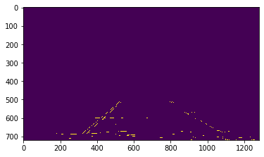

```python
bright_image = np.array(255*(image/255)**0.1, dtype = 'uint16')
gray_image = cv2.cvtColor(image, cv2.COLOR_RGB2GRAY)

canny_image = cv2.Canny(gray_image, 100, 200)
cropped_image = region_of_interest(canny_image,
                np.array([region_of_interest_vertices], np.int32),)
plt.imshow(cropped_image)
```

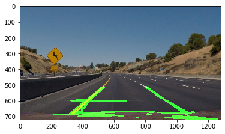

```python
lines = cv2.HoughLinesP(cropped_image,
                        rho=6,
                        theta=np.pi/180,
                        threshold=100,
                        lines=np.array([]),
                        minLineLength=1,
                        maxLineGap=150)



image_with_lines = drow_the_lines(image, lines)
plt.imshow(image_with_lines);
```

## Deleting the horzontal lines

### Before deleting them we have around 50 lines after deleting them we get arround 20 lines. But we only want 2 lines.

```python
houghLines = []
for line in lines:
    line = line.ravel()
    print(line)
    houghLines.append(HoughLine(line))


print(len(houghLines)," Slopes Beofre deleting the repeated  : ")
for line in houghLines:
    print(line.getSlope())

finalLines = []
for line in houghLines :
    if  line.getSlope() >0.4 or  line.getSlope() < -0.5:
        finalLines.append(line)
        print(line.getSlope())


image_with_lines = drow_the_lines3(image, finalLines)
```

```
[587 670 829 670]
[218 688 347 685]
[343 685 533 514]
[314 685 481 549]
[810 685 820 685]
[371 700 573 693]
[ 872  565 1076  678]
[ 902  676 1021  678]
[321 684 387 627]
[330 675 475 675]
[822 671 853 671]
[315 685 333 685]
[ 931  706 1158  718]
[390 602 675 602]
[324 680 649 669]
[ 974  695 1080  704]
[ 864  562 1073  678]
[321 683 369 684]
[496 544 525 518]
[ 925  705 1244  717]
[670 669 680 669]
[327 678 656 695]
[341 685 537 515]
[394 600 439 598]
[745 706 754 706]
[522 696 584 694]
[ 802  510 1112  719]
[821 688 835 688]
[1233  717 1255  718]
[346 663 418 601]
[375 684 516 517]
[1058  702 1177  706]
[377 653 529 516]
[326 599 444 593]
[379 699 598 688]
[ 804  515 1106  718]
[1022  678 1108  674]
[ 938  705 1092  707]
[1071  674 1112  673]
[466 560 532 510]
```

[output cut: 45 more lines]

```
0.08614232209737828
0.125
-0.9
-0.8143712574850299
0.553921568627451
-0.8636363636363636
0.5550239234449761
-0.896551724137931
-0.8673469387755102
0.6741935483870968
-0.8611111111111112
-1.1843971631205674
-0.9013157894736842
0.6721854304635762
-0.7575757575757576
```

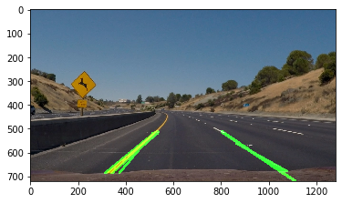

```python
plt.imshow(image_with_lines)
```

### This function will take all the lines and garuntees to return only two lines

```python
def deleteRepeatedLines(houghLines):
    minPos = 10000
    maxNeg  = -10000
    result = []
    global defaultLeftLine
    global defaultRightLine
    #defaultLeftLine = HoughLine(p1 = Point(300,720), p2 = Point(620,510))
    #defaultRightLine = HoughLine( p1 = Point(1280,720),p2 = Point(826,510))

    for line in houghLines:
        if line.getSlope() >0 and line.getSlope() < minPos :
            #minPos = lines.getSlope()
            #resultP.append(line)
            minPos = line.getSlope()

        if line.getSlope() <0 and line.getSlope() > maxNeg :
            #minPos = lines.getSlope()
            #resultP.append(line)
            maxNeg = line.getSlope()

    for line in houghLines :
        if line.getSlope() == minPos or line.getSlope() == maxNeg :
            result.append(line)

    tmp = result.copy()
    if len(tmp) >=2 :
        for line in result :
            if line.getSlope() <0:
                tmp[0] = line
            else:
                tmp[1] = line

        result = tmp
    elif len(tmp) ==1 :
        if result[0].getSlope() < 0 :
            tmp[0] = result[0]
            #tmp.append(HoughLine( p1 = Point(1280,720),p2 = Point(826,510)))
            tmp.append(defaultRightLine)
        else :
            tmp[0] = result[0]
            #tmp.append(HoughLine(p1 = Point(300,720), p2 = Point(620,510)))
            tmp.append(defaultLeftLine)

        result = tmp
    elif len(tmp) ==0:
        #tmp.append(HoughLine(p1 = Point(300,720), p2 = Point(620,510)))
        #tmp.append(HoughLine( p1 = Point(1280,720),p2 = Point(826,510)))
        tmp.append(defaultLeftLine)
        tmp.append(defaultRightLine)


        result = tmp

    #defaultLeftLine = result[0]
    #defaultRightLine = result[1]

    return result
```

```
Deleteing Repeated Slopes :
```

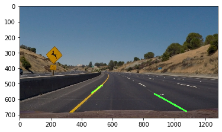

```python
print("Deleteing Repeated Slopes : ")
finalLines = deleteRepeatedLines(finalLines)
image_with_lines = drow_the_lines3(image, finalLines)
plt.imshow(image_with_lines)
```

### Now that we have two lines , we can extend them to be the lanes with this method

```python
def getCompleterPoints(img,line):
    img = np.copy(img)
    blank_image = np.zeros((img.shape[0], img.shape[1], 3), dtype=np.uint8)
    height = img.shape[0]
    y_upper = int(height/(3/2))+30
    y_lower = height

    upperPoint = Point(0,y_upper)
    lowerPoint = Point(0,y_lower)

    upperPoint.x = int(((y_upper - line.p1.y)+(line.getSlope()*line.p1.x))/line.getSlope())
    lowerPoint.x = int(((y_lower - line.p1.y)+(line.getSlope()*line.p1.x))/line.getSlope())
    result = [upperPoint,lowerPoint]

    return result
```

## We got our lane!

#### Note , this is not magic

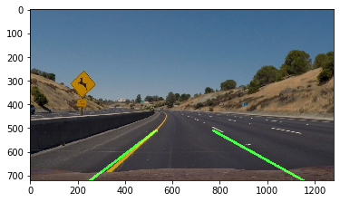

```python
finalLines[1] =getCompleterPoints(image,finalLines[1])
finalLines[0] =getCompleterPoints(image,finalLines[0])

image_with_lines = drow_the_lines2(image, finalLines)


plt.imshow(image_with_lines)
```

## To detect the collision we tried to detect the box area that is inside the lane by calculating the intersection of the box with the lane to get the intersection points and calculate the area

spoilers : this didnt work

```
[250, 600, 500, 600]  Vs  510
Lower Intersection:  (280, 700)
Upper Intersection:  (412, 600)
```

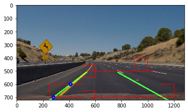

```python
img = generateTest()
# Returns the intersections and draws a cricle at their locations
leftIntersections = isLeftIntersected_v1(box1)



plt.imshow(img)
```

### There are too many cases to code , so we thought of another way :

### -Convolving the boxes to determine the intersection size

#### To do so we make the detected lane black and then convolve the box with the image to see if the % of the box that is in the lane

### So we created the method detectLane(img) that does all the explained code above and converts the lane into black

#### The method is too long so i cant explained it here

# Testing the method

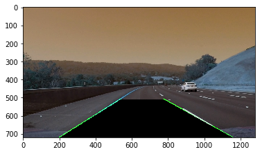

```python
img_name = "test3.jpg"
img = cv2.imread(img_name)
image_with_lanes = detectLane(img)
plt.imshow(image_with_lanes);
```

## Several Tests

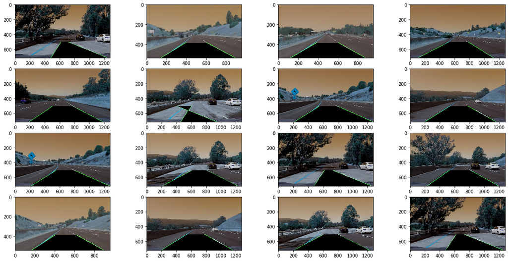

```python
imgs = [cv2.imread(file) for file in glob.glob("*.jpg")]

for i in range(0,len(imgs)):
    imgs[i] = detectLane(imgs[i])

fig , axes = plt.subplots(4,4)
fig.set_size_inches(20,10)
axes = axes.flatten()
for i in range(0,16) :
    plt.sca(axes[i])
    plt.imshow(imgs[i])
```

### Getting the score

#### Again its too long to be explained but in summary it counts the percentage of the box that is in the lane and the distance of the box from the lane

#### following is a snapshot from the method

```
slicedImage = img[box.y:box.y+box.h,box.x:box.x+box.w]
slicedImageArea = slicedImage.shape[0] * slicedImage.shape[1]
unique , counts = np.unique(slicedImage[:,:,0],return_counts=True)
num_of_black = counts[0]
areaPercentage = num_of_black/slicedImageArea
dist = distanceFromBaseLine(img,box)
```

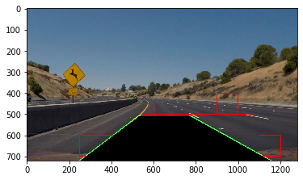

```python
img = generateTest(black=True)
plt.imshow(img)
```

```
(0.61216, 20.0)
```

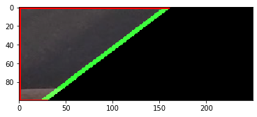

```python
getBoxScore(img,box1,withDistance=True,boxPercentage=True)
```

### That is how we find the score of the car

#### The remaining is to see if the car gets a high score in multiple frames , then we now if there is a collision